# Тест

#### №1

Пусть потребитель, обладающий положительным фиксированным доходом, расходует его на приобретение двух благ. Какое/какие из следующих утверждений верны?

1. Все доступные потребителю наборы благ лежат на бюджетной линии.
2. В осях, где по горизонтали откладывается объем потребления первого блага, а по вертикали – объем потребления второго блага, наклон бюджетной линии отрицателен и равен отношению цены первого блага к цене второго.
3. Максимальное количество первого блага, доступное потребителю, равно его доходу, деленному на цену единицы первого блага.

#### №2

Пусть потребитель, обладающий положительным фиксированным доходом, расходует его на приобретение двух благ. Какое/какие из следующих утверждений верны?

1. Все доступные потребителю наборы благ лежат на бюджетной линии.
2. В осях, где по горизонтали откладывается объем потребления первого блага, а по вертикали – объем потребления второго блага, наклон бюджетной линии отрицателен и равен отношению цены первого блага к цене второго.
3. Максимальное количество первого блага, доступное потребителю, равно его доходу, деленному на цену единицы первого блага.

#### №3

В каком из следующих случаев бюджетное множество индивида с положительным фиксированным доходом, потребляющего два блага, останется неизменным:

1. если все цены возрастут в три раза, а доход потребителя увеличится на тридцать процентов;
2. если все цены уменьшатся на пятьдесят процентов, а доход уменьшится в полтора раза;
3. если цены вырастут на двадцать процентов, а доход потребителя возрастет в два раза;
4. если все цены увеличатся в полтора раза, а доход потребителя увеличится на пятьдесят процентов;
5. если цена первого блага снизится на три единицы, а цена второго блага возрастет на три единицы?

> В тестах 4 – 8 рассмотрите рис. 1, на котором схематично изображена бюджетная линия потребителя с положительным доходом. Пусть цена единицы первого блага равна 3 д.е.

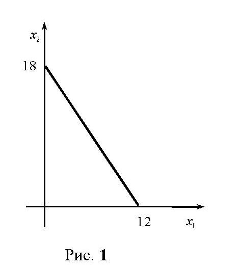

#### №4

Доход потребителя равен:

1. 4
2. 6
3. 30
4. 36
5. 54

#### №5

Цена единицы второго блага равна:

1. $\frac{1}{18}$
2. $\frac{2}{3}$
3. 2
4. 4
5. 6

#### №6

Какой вид имеет бюджетное множество, если цена первого блага составляет 3 д.е только при покупке первых пяти единиц, а при покупке свыше этого объема вводится адвалорная субсидия в размере 2/3? Выберите из вариантов, схематично изображенных на рис. 2.

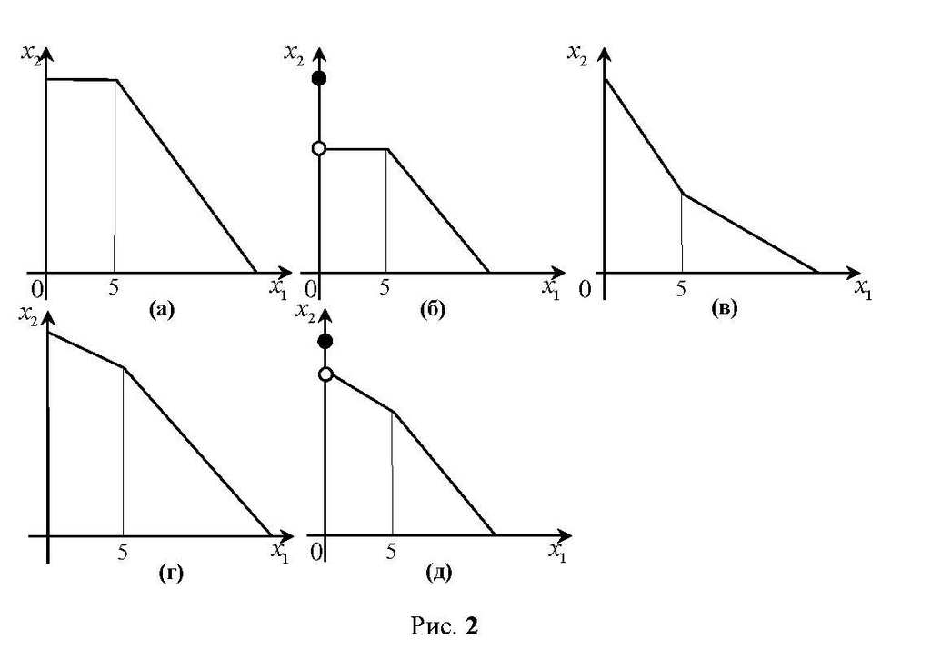

1. рисунок 2а
2. рисунок 2б
3. рисунок 2в
4. рисунок 2г
5. рисунок 2д

#### №7

Максимальное количество первого блага, которое сможет купить потребитель в условиях, указанных в тесте 1.6, составляет:

1. 15,5
2. 18
3. 21
4. 24
5. 26

#### №8

Какие условия продажи преобразуют бюджетное множество на рис. 1 в бюджетное множество на рис. 2б?

1. Потребитель получает не подлежащий продаже купон на бесплатное получение пяти единиц первого блага.
2. Потребитель платит фиксированную сумму денег, позволяющую получить пять единиц первого блага.
3. При покупке свыше пяти единиц первого блага цена этого блага возрастает.
4. При покупке свыше пяти единиц первого блага цена этого блага снижается.
5. Потребитель платит фиксированную сумму денег за право приобретения каждой единицы первого блага по некоторой положительной цене.

#### №9

Пусть потребитель приобрел набор x при ценах р и набор у при ценах q, наборы х и у не совпадают. Известно, что потребитель полностью тратит свой доход на приобретение наборов благ. Тогда, если предпочтения индивида согласуются со слабой аксиомой выявленных предпочтений, то:

1. набор у недоступен при ценах р;
2. набор х недоступен при ценах q;
3. если набор х доступен при ценах q, то набор у недоступен при ценах р;
4. стоимость набора х при ценах р должна быть равна стоимости набора у при ценах q;
5. стоимость набора у при ценах q не равна стоимости набора x при ценах p.

#### №10

Пусть потребитель приобрел набор х при ценах р и набор у при ценах q, наборы х и у не совпадают. Известно, что потребитель полностью тратит свой доход на приобретение наборов благ. Какое/какие из следующих утверждений верны?

1. Согласно WARP, если набор x выявленно предпочитается набору y, то набор y должен выявленно предпочитаться набору x.
2. Если набор y выявленно предпочитается набору x и был недоступен, когда приобретался набор x, то наборы x и y выявленно не сравнимы.
3. Если набор y выявленно предпочитается набору x и был недоступен, когда приобретался набор x, то WARP выполнена.

#### №11

Известно, что потребитель тратит на покупку каждого набора весь доход. Предположим, при ценах (2, 4) потребитель выбрал набор (5, 3), а при ценах (3, 2) потребитель выбрал набор (4, 5). Какое из следующих утверждений верно?

1. Набор (4, 5) выявленно предпочитается набору (5, 3) и предпочтения согласуются с WARP.
2. Набор (5, 3) выявленно предпочитается набору (4, 5) и предпочтения не согласуются с WARP.
3. Набор (4, 5) выявленно предпочитается набору (5, 3) и предпочтения не согласуются с WARP.
4. Набор (5, 3) выявленно предпочитается набору (4, 5) и предпочтения согласуются с WARP.
5. Наборы (5, 3) и (4, 5) выявленно не сравнимы.

#### №12

Пусть потребитель приобрел набор х при ценах р и набор у при ценах q, наборы х и у не совпадают. Известно, что потребитель полностью тратит свой доход на приобретение наборов. В каком/каких из следующих случаев, изображенных на рис. 3, слабая аксиома выявленных предпочтений выполнена?

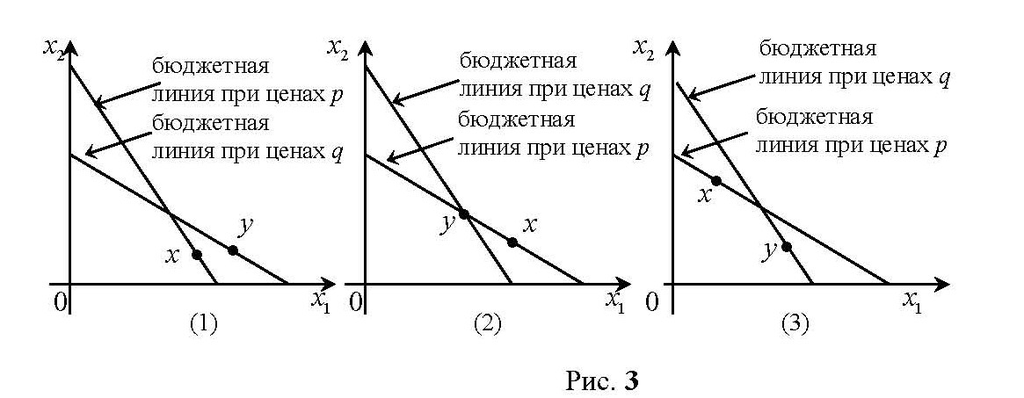

1. только (1)
2. только (1) и (2)
3. только (2)
4. только (2) и (3)
5. только (3)

#### №13

Пусть потребитель при цене первого блага, равной 10 д.е., и некоторой цене второго блага z выбрал набор (4, 6), а при ценах (20, 30) выбрал набор (2, 8). Потребитель тратит весь свой доход на оба блага. При каком из следующих значений неизвестной цены второго блага z слабая аксиома выявленных предпочтений нарушается?

1. 40
2. 30
3. 20
4. 15
5. 10

#### №14

Рассмотрите пенсионерку, которая тратит весь доход на оплату электроэнергии и остальные товары и услуги. На оплату электроэнергии пенсионерка получает адвалорную субсидию по ставке s, где значение s больше нуля, но меньше единицы, (т.е. субсидия составляет долю s от расходов пенсионерки на оплату электроэнергии). В правительстве обсуждается программа, согласно которой адвалорная субсидия по ставке s заменяется персональной компенсацией, которая в точности равна расходам государства на адвалорное субсидирование пенсионерки по ставке s. Какое/какие утверждения верны, если её поведение не нарушает WARP?

1. Пенсионерка точно не проиграет от такой замены.
2. Пенсионерка может увеличить потребление электроэнергии.
3. Если программа будет принята с поправками, в результате которых адвалорная субсидия будет заменена персональной компенсацией, которая меньше расходов государства на адвалорное субсидирование по ставке s, то положение пенсионерки неизбежно ухудшится.

> В тестах 15 – 17 рассмотрите индивида W, полностью расходующего весь свой доход, равный 2000 д.е. в месяц, на оплату Интернета и остальные товары и услуги. Известно, что в январе индивид W заключил договор с Интернет-провайдером «Центел», и, как новый клиент, получил 8 Гб Интернет-трафика в месяц бесплатно, а цена каждого Гб трафика сверх этого количества составляла 200 д.е. В феврале индивид перестал быть новым клиентом и был переведен на тариф с абонентской платой в размере 200 д.е., включающей 6 Гб трафика. Согласно новому тарифу Интернет-трафик в объеме, превышающем 6 Гб, оплачивается по цене 100 д.е. за каждый Гб. Предположим, известно, что при февральском тарифе индивид использовал 14 Гб трафика в месяц.

#### №15

Если бы при январском тарифе индивид использовал 14 Гб, то какая сумма осталась бы у него на оплату остальных товаров и услуг?

1. 1400
2. 1200
3. 1000
4. 800
5. 600

#### №16

Уравнение бюджетной линии при январском тарифе имеет вид:

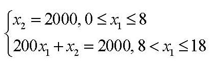

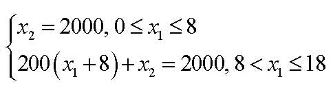

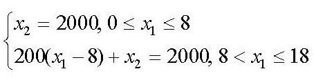

#### №17

По имеющейся информации (подсказка: изобразите обе бюджетных линии на одном рисунке и отметьте выбор февраля):

1. мы не можем точно сказать, какой тариф (январский или февральский) для индивида W предпочтительней;
2. мы можем сделать вывод, что тариф января для индивида W точно не хуже, чем тариф февраля;
3. мы можем сделать вывод, что тариф февраля для индивида W точно не хуже, чем тариф января; 4 .мы можем сделать вывод, что тарифы января и февраля для индивида W точно эквиваленты;
4. мы можем сделать вывод, что если потребитель W в январе использовал 14Гб трафика то январский тариф для него лучше февральского.